# Proyecto 1 - Predecir la calidad del vino

## **Proyecto 1 - Predecir la calidad del vino**

> > **Especialización en Machine Learning**

> > **Machine Learning**

> > **Universidad EAN 2024**

> > *Profesor: Sergio David Díaz*

> > **Integrantes de grupo:**
> > - Luis Fernando Cruz.
> > - Daniel Alejandro Rodríguez.
> > - Luisa Fernanda Tirado León.

```python
pip install ucimlrepo
```

```python
from ucimlrepo import fetch_ucirepo

# fetch dataset
wine_quality = fetch_ucirepo(id=186)

# data (as pandas dataframes)
X = wine_quality.data.features
y = wine_quality.data.targets

# metadata
print(wine_quality.metadata)

# variable information
print(wine_quality.variables)
```

```
{'uci_id': 186, 'name': 'Wine Quality', 'repository_url': 'https://archive.ics.uci.edu/dataset/186/wine+quality', 'data_url': 'https://archive.ics.uci.edu/static/public/186/data.csv', 'abstract': 'Two datasets are included, related to red and white vinho verde wine samples, from the north of Portuga…
                    name     role         type demographic  \
0          fixed_acidity  Feature   Continuous        None
1       volatile_acidity  Feature   Continuous        None
2            citric_acid  Feature   Continuous        None
3         residual_sugar  Feature   Continuous        None
4              chlorides  Feature   Continuous        None
5    free_sulfur_dioxide  Feature   Continuous        None
6   total_sulfur_dioxide  Feature   Continuous        None
7                density  Feature   Continuous        None
8                     pH  Feature   Continuous        None
9              sulphates  Feature   Continuous        None
10               alcohol  Feature   Continuous        None
11               quality   Target      Integer        None
12                 color    Other  Categorical        None

               description units missing_values
0                     None  None             no
1                     None  None             no
2                     None  None             no
3                     None  None             no
4                     None  None             no
5                     None  None             no
6                     None  None             no
7                     None  None             no
8                     None  None             no
9                     None  None             no
10                    None  None             no
11  score between 0 and 10  None             no
12            red or white  None             no
```

```python
import pandas as pd
import numpy as np
from sklearn.model_selection import train_test_split
from sklearn.preprocessing import StandardScaler
from sklearn.linear_model import LinearRegression, LogisticRegression
from sklearn.metrics import mean_squared_error, accuracy_score, confusion_matrix
import matplotlib.pyplot as plt
```

```python
import os
print(os.getcwd())
print(os.listdir('.'))
```

```
C:\Users\Luisf\Python_2024
['.ipynb_checkpoints', '1. Estadistica y propabilidad', '2. Ejercicios varios', '3. Colsanitas', '4. Machine Learning I']
```

```python
import os

# Cambiar al directorio donde se encuentra el archivo
os.chdir('4. Machine Learning I')
print(os.getcwd())
print(os.listdir('.'))
```

```
C:\Users\Luisf\Python_2024\4. Machine Learning I
['.ipynb_checkpoints', 'Actividad 2.ipynb', 'winequality-red.csv']
```

```python
data = pd.read_csv('winequality-red.csv')
print(data.head())
```

```
  fixed acidity;"volatile acidity";"citric acid";"residual sugar";"chlorides";"free sulfur dioxide";"total sulfur dioxide";"density";"pH";"sulphates";"alcohol";"quality"
0   7.4;0.7;0;1.9;0.076;11;34;0.9978;3.51;0.56;9.4;5
1   7.8;0.88;0;2.6;0.098;25;67;0.9968;3.2;0.68;9.8;5
2  7.8;0.76;0.04;2.3;0.092;15;54;0.997;3.26;0.65;...
3  11.2;0.28;0.56;1.9;0.075;17;60;0.998;3.16;0.58...
4   7.4;0.7;0;1.9;0.076;11;34;0.9978;3.51;0.56;9.4;5
```

Una exploración descriptiva de los datos que incluya:

- 1. Descripción de las variables de la base.
- 1. Tratamiento de valores nulos, si aplica.
- 1. Identificación de variables predictoras y la variable objetivo.
- 1. Transformaciones necesarias para entrenar el modelo con los datos revisados.
- 1. Un entrenamiento de las diferentes regresiones y una aplicación de diversas técnicas (regularización) para generar los modelos.
- 1. Un resumen de los estadísticos de validación de los modelos.
- 1. Conclusiones de la experiencia.

```python
# 1. Descripcion de las variables de la base
print(data.describe())
```

```
       fixed acidity;"volatile acidity";"citric acid";"residual sugar";"chlorides";"free sulfur dioxide";"total sulfur dioxide";"density";"pH";"sulphates";"alcohol";"quality"
count                                                1599
unique                                               1359
top     7.2;0.36;0.46;2.1;0.074;24;44;0.99534;3.4;0.85...
freq                                                    4
```

```python
print(data.info())
```

```
<class 'pandas.core.frame.DataFrame'>
RangeIndex: 1599 entries, 0 to 1598
Data columns (total 1 columns):
 #   Column                                                                                                                                                                   Non-Null Count  Dtype
---  ------                                                                                                                                                                   --------------  -----
 0   fixed acidity;"volatile acidity";"citric acid";"residual sugar";"chlorides";"free sulfur dioxide";"total sulfur dioxide";"density";"pH";"sulphates";"alcohol";"quality"  1599 non-null   object
dtypes: object(1)
memory usage: 12.6+ KB
None
```

```python
print(data.isnull().sum())
```

```
fixed acidity;"volatile acidity";"citric acid";"residual sugar";"chlorides";"free sulfur dioxide";"total sulfur dioxide";"density";"pH";"sulphates";"alcohol";"quality"    0
dtype: int64
```

```python
data = pd.read_csv('winequality-red.csv', delimiter=';')
print(data.describe())
print(data.info())
```

```
       fixed acidity  volatile acidity  citric acid  residual sugar  \
count    1599.000000       1599.000000  1599.000000     1599.000000
mean        8.319637          0.527821     0.270976        2.538806
std         1.741096          0.179060     0.194801        1.409928
min         4.600000          0.120000     0.000000        0.900000
25%         7.100000          0.390000     0.090000        1.900000
50%         7.900000          0.520000     0.260000        2.200000
75%         9.200000          0.640000     0.420000        2.600000
max        15.900000          1.580000     1.000000       15.500000

         chlorides  free sulfur dioxide  total sulfur dioxide      density  \
count  1599.000000          1599.000000           1599.000000  1599.000000
mean      0.087467            15.874922             46.467792     0.996747
std       0.047065            10.460157             32.895324     0.001887
min       0.012000             1.000000              6.000000     0.990070
25%       0.070000             7.000000             22.000000     0.995600
50%       0.079000            14.000000             38.000000     0.996750
75%       0.090000            21.000000             62.000000     0.997835
max       0.611000            72.000000            289.000000     1.003690

                pH    sulphates      alcohol      quality
count  1599.000000  1599.000000  1599.000000  1599.000000
mean      3.311113     0.658149    10.422983     5.636023
std       0.154386     0.169507     1.065668     0.807569
min       2.740000     0.330000     8.400000     3.000000
25%       3.210000     0.550000     9.500000     5.000000
50%       3.310000     0.620000    10.200000     6.000000
75%       3.400000     0.730000    11.100000     6.000000
max       4.010000     2.000000    14.900000     8.000000
<class 'pandas.core.frame.DataFrame'>
RangeIndex: 1599 entries, 0 to 1598
Data columns (total 12 columns):
 #   Column                Non-Null Count  Dtype
---  ------                --------------  -----
 0   fixed acidity         1599 non-null   float64
 1   volatile acidity      1599 non-null   float64
 2   citric acid           1599 non-null   float64
 3   residual sugar        1599 non-null   float64
 4   chlorides             1599 non-null   float64
 5   free sulfur dioxide   1599 non-null   float64
 6   total sulfur dioxide  1599 non-null   float64
 7   density               1599 non-null   float64
 8   pH                    1599 non-null   float64
 9   sulphates             1599 non-null   float64
 10  alcohol               1599 non-null   float64
 11  quality               1599 non-null   int64
dtypes: float64(11), int64(1)
memory usage: 150.0 KB
None
```

```python
# Determinar la cantidad de variables y registros
num_variables = data.shape[1]
num_registros = data.shape[0]

# Identificar variables numéricas y cualitativas
variables_numericas = data.select_dtypes(include=['float64', 'int64']).columns.tolist()
variables_cualitativas = data.select_dtypes(include=['object']).columns.tolist()

# Resumen de la información
print("Número de variables:", num_variables)
print("Número de registros:", num_registros)
print("Variables numéricas:", variables_numericas)
print("Variables cualitativas:", variables_cualitativas)

# Mostrar estadísticas descriptivas para las variables numéricas
print("\nEstadísticas descriptivas para variables numéricas:")
print(data.describe())

# Si hay variables cualitativas, mostrar los primeros valores únicos para cada una
if variables_cualitativas:
    print("\nValores únicos para variables cualitativas:")
    for var in variables_cualitativas:
        print(f"{var}: {data[var].unique()[:5]}")  # Mostrar los primeros 5 valores únicos
else:
    print("\nNo hay variables cualitativas en el dataset.")
```

```
Número de variables: 12
Número de registros: 1599
Variables numéricas: ['fixed acidity', 'volatile acidity', 'citric acid', 'residual sugar', 'chlorides', 'free sulfur dioxide', 'total sulfur dioxide', 'density', 'pH', 'sulphates', 'alcohol', 'quality']
Variables cualitativas: []

Estadísticas descriptivas para variables numéricas:
       fixed acidity  volatile acidity  citric acid  residual sugar  \
count    1599.000000       1599.000000  1599.000000     1599.000000
mean        8.319637          0.527821     0.270976        2.538806
std         1.741096          0.179060     0.194801        1.409928
min         4.600000          0.120000     0.000000        0.900000
25%         7.100000          0.390000     0.090000        1.900000
50%         7.900000          0.520000     0.260000        2.200000
75%         9.200000          0.640000     0.420000        2.600000
max        15.900000          1.580000     1.000000       15.500000

         chlorides  free sulfur dioxide  total sulfur dioxide      density  \
count  1599.000000          1599.000000           1599.000000  1599.000000
mean      0.087467            15.874922             46.467792     0.996747
std       0.047065            10.460157             32.895324     0.001887
min       0.012000             1.000000              6.000000     0.990070
25%       0.070000             7.000000             22.000000     0.995600
50%       0.079000            14.000000             38.000000     0.996750
75%       0.090000            21.000000             62.000000     0.997835
max       0.611000            72.000000            289.000000     1.003690

                pH    sulphates      alcohol      quality
count  1599.000000  1599.000000  1599.000000  1599.000000
mean      3.311113     0.658149    10.422983     5.636023
std       0.154386     0.169507     1.065668     0.807569
min       2.740000     0.330000     8.400000     3.000000
25%       3.210000     0.550000     9.500000     5.000000
50%       3.310000     0.620000    10.200000     6.000000
75%       3.400000     0.730000    11.100000     6.000000
max       4.010000     2.000000    14.900000     8.000000

No hay variables cualitativas en el dataset.
```

```python
X = data.drop('quality', axis=1)
y = data['quality']
y_binary = (y >= 6).astype(int)
```

```python
scaler = StandardScaler()
X_scaled = scaler.fit_transform(X)
```

```python
X_train, X_test, y_train, y_test = train_test_split(X_scaled, y, test_size=0.2, random_state=42)
X_train_log, X_test_log, y_train_log, y_test_log = train_test_split(X_scaled, y_binary, test_size=0.2, random_state=42)
```

```python
# Regresión Lineal
model_linear = LinearRegression()
model_linear.fit(X_train, y_train)
y_pred_linear = model_linear.predict(X_test)
mse_linear = mean_squared_error(y_test, y_pred_linear)
print("MSE para Regresión Lineal:", mse_linear)
```

```
MSE para Regresión Lineal: 0.39002514396395493
```

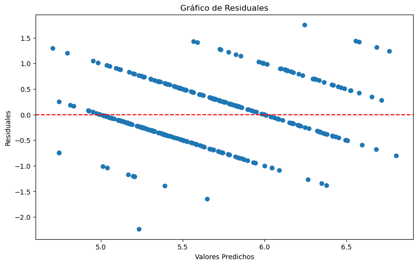

```
Coeficientes del Modelo: [ 0.04018122 -0.1792372  -0.0274236   0.00925231 -0.08499703  0.05884439
 -0.11984784 -0.0195308  -0.06076105  0.14253987  0.30030663]
MSE para Regresión Lineal: 0.39002514396395493
R^2 para Regresión Lineal: 0.403180341279622
```

```python
from sklearn.metrics import r2_score

# Calcular residuales
residuales = y_test - y_pred_linear

# Calcular R^2
r2 = r2_score(y_test, y_pred_linear)

# Visualizar residuales
import matplotlib.pyplot as plt
plt.figure(figsize=(10, 6))
plt.scatter(y_pred_linear, residuales)
plt.axhline(0, color='red', linestyle='--')
plt.xlabel('Valores Predichos')
plt.ylabel('Residuales')
plt.title('Gráfico de Residuales')
plt.show()

print("Coeficientes del Modelo:", model_linear.coef_)
print("MSE para Regresión Lineal:", mse_linear)
print("R^2 para Regresión Lineal:", r2)
```

# Analisis de resultados Regresion lineal

Los residulaes no estan no estan distribuido alrededore de la linea roja en cero, sino que estan dfistribuidosen un patron descendente, esto indica que hay una tendencia sistematica de errores que puede deberse a que el modelo no esta capturando las relaciones no lineanes o interascciones entre los datos.

Por otra parte podemos identificar que la varianza de los errores cambia con el nivel de los valores predichos loo que se conoce como heteroscedasticidad, lo cual termina afectando el modelo

```python
# Regresión Logística
model_logistic = LogisticRegression()
model_logistic.fit(X_train_log, y_train_log)
y_pred_log = model_logistic.predict(X_test_log)
accuracy_log = accuracy_score(y_test_log, y_pred_log)
conf_matrix_log = confusion_matrix(y_test_log, y_pred_log)
print("Precisión para Regresión Logística:", accuracy_log)
print("Matriz de Confusión:\n", conf_matrix_log)
```

```
Precisión para Regresión Logística: 0.740625
Matriz de Confusión:
 [[105  36]
 [ 47 132]]
```

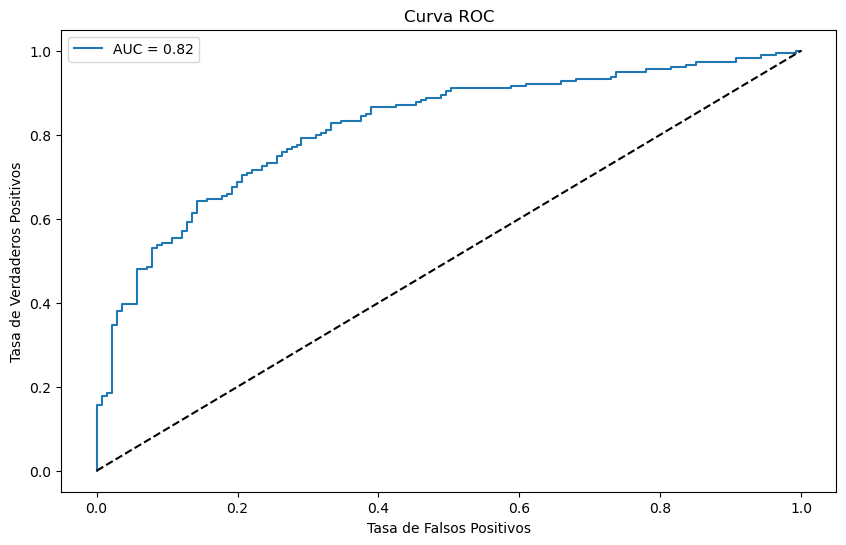

```
Coeficientes del Modelo: [[ 0.20493695 -0.52772887 -0.19826746  0.02181377 -0.17714462  0.30863425
  -0.59725147 -0.05203793 -0.04970298  0.4492984   0.94256362]]
Precisión para Regresión Logística: 0.740625
Recall para Regresión Logística: 0.7374301675977654
F1 Score para Regresión Logística: 0.760806916426513
AUC para Regresión Logística: 0.8190895043385238
```

```python
from sklearn.metrics import roc_curve, roc_auc_score, recall_score, f1_score

# Calcular métricas adicionales
recall = recall_score(y_test_log, y_pred_log)
f1 = f1_score(y_test_log, y_pred_log)
roc_auc = roc_auc_score(y_test_log, model_logistic.predict_proba(X_test_log)[:, 1])

# Curva ROC
fpr, tpr, thresholds = roc_curve(y_test_log, model_logistic.predict_proba(X_test_log)[:, 1])
plt.figure(figsize=(10, 6))
plt.plot(fpr, tpr, label=f'AUC = {roc_auc:.2f}')
plt.plot([0, 1], [0, 1], 'k--')
plt.xlabel('Tasa de Falsos Positivos')
plt.ylabel('Tasa de Verdaderos Positivos')
plt.title('Curva ROC')
plt.legend()
plt.show()

print("Coeficientes del Modelo:", model_logistic.coef_)
print("Precisión para Regresión Logística:", accuracy_log)
print("Recall para Regresión Logística:", recall)
print("F1 Score para Regresión Logística:", f1)
print("AUC para Regresión Logística:", roc_auc)
```

# Analisis de resultados Regresion Logistica

El valor del AUC que obtuvimos es de 0.82 el cual representa un resultado muy bueno lo cual indica que que el modelo esta teniendo una buena capacidad para distinguir entra clase alta y baja de la calidad del vino, por otra parte nos esta dando una precision del 74% de las predicciones realizadas lo que se traduce en datos de alta calidad

# Regularizacion

De acuerdo a los resultados obtenidos haremos unas regularizaciones teniendo en cuenta esto iniciaremos con dos tecnicas para la regresion lineal y regresion logistica.

- Ridge Regression (Regrersion Cresta)
- Lasso Regression (Regresion Lasso)

```python
from sklearn.linear_model import Ridge, Lasso

# Configurando modelos Ridge y Lasso con un valor de alpha
alpha = 1.0  # Este valor puede ser ajustado para explorar diferentes grados de regularización

# Ridge Regression
ridge_model = Ridge(alpha=alpha)
ridge_model.fit(X_train, y_train)
y_pred_ridge = ridge_model.predict(X_test)
mse_ridge = mean_squared_error(y_test, y_pred_ridge)
print("MSE para Ridge Regression:", mse_ridge)
```

```
MSE para Ridge Regression: 0.39003658082449677
```

```python
# Lasso Regression
lasso_model = Lasso(alpha=alpha)
lasso_model.fit(X_train, y_train)
y_pred_lasso = lasso_model.predict(X_test)
mse_lasso = mean_squared_error(y_test, y_pred_lasso)
print("MSE para Lasso Regression:", mse_lasso)
```

```
MSE para Lasso Regression: 0.6571600689645265
```

```python
from sklearn.linear_model import LogisticRegression

# Regresión Logística con L1 Regularización (Lasso)
model_l1 = LogisticRegression(penalty='l1', solver='saga', C=1.0, max_iter=10000)
model_l1.fit(X_train, y_train)

# Regresión Logística con L2 Regularización (Ridge)
model_l2 = LogisticRegression(penalty='l2', solver='lbfgs', C=1.0, max_iter=10000)
model_l2.fit(X_train, y_train)

# Regresión Logística con Elastic Net Regularización
model_en = LogisticRegression(penalty='elasticnet', solver='saga', l1_ratio=0.5, C=1.0, max_iter=10000)
model_en.fit(X_train, y_train)
```

```
LogisticRegression(l1_ratio=0.5, max_iter=10000, penalty='elasticnet',
                   solver='saga')
```

# Analisis resultados de ambas regresiones

Basados en los resultados de ambas regresiones, en este caso podemos decir que la Rgeresion Logistica párece ser un mejor modelo para este conjunto de datos trabajado toda vez que las metricas arrojaron dato de alta calidad, por este motivo la regresion logistica es el modelo mas adecuada para clasificar la calidad del vino, por otra lado los datos arrojados por la regresion lineal sugieren que se necesitan modelos mas complejos o ajustes adicionales que permitan capturar adecuadamente la reelacion entre las variables trabajadas.